# obt_fab_master

Lisa

2024-03-27

Небольшой пример обработки микробных данных на примере анализа измкенчивости микробиома литторин (данные изменены)

Осторожно, встречаются неоптимизированные действия, неединообразный код и конфликты пакетов.

# 1 Основные действия до фильтрации

## 1.1 Загрузка данных

```
## phyloseq-class experiment-level object
## otu_table()   OTU Table:         [ 7920 taxa and 80 samples ]
## sample_data() Sample Data:       [ 80 samples by 12 sample variables ]
## tax_table()   Taxonomy Table:    [ 7920 taxa by 8 taxonomic ranks ]
```

```
##  [1] "L1_L_fab_gut2"    "L1_L_nod_BF2"     "L1_L_obt_gut1"    "L1_L_obt_gut2"
##  [5] "L1_L_obt_gut3"    "L1_L_obt_gut5"    "L1_L_obt_gut6"    "L1_L_obt_gut7"
##  [9] "L1_L_obt_gut8"    "L1_L_ser_BF1"     "L1_L_ser_BF2"     "L1_L_stones_BF1"
## [13] "L1_L_ves_BF1"     "L1_L_ves_BF2"     "L1_L_ves_BF3"     "L1_U_obt_gut1"
## [17] "L1_U_obt_gut2"    "L1_U_obt_gut3"    "L1_U_obt_gut7"    "L11_L_fab_gut2"
## [21] "L11_L_fab_gut3"   "L11_L_fab_gut4"   "L11_L_fab_gut5"   "L11_L_fab_gut6"
## [25] "L11_L_fab_gut7"   "L11_L_fab_gut8"   "L11_L_fab_tent1"  "L11_L_fab_tent2"
## [29] "L11_L_fill_BF1"   "L11_L_fill_BF2"   "L11_L_fill_BF3"   "L11_L_nod_BF2"
## [33] "L11_L_nod_BF3"    "L11_L_obt_gut3"   "L11_L_obt_gut4"   "L11_L_obt_gut5"
## [37] "L11_L_obt_gut6"   "L11_L_obt_gut7"   "L11_L_obt_gut8"   "L11_L_obt_tent1"
## [41] "L11_L_obt_tent2"  "L11_L_stones_BF1" "L11_L_stones_BF2" "L11_L_stones_BF3"
## [45] "L11_U_fill_BF1"   "L11_U_nod_BF2"    "L11_U_obt_gut1"   "L11_U_obt_gut2"
## [49] "L11_U_obt_gut3"   "L11_U_obt_gut4"   "L11_U_obt_gut5"   "L11_U_obt_gut8"
## [53] "L11_U_obt_tent2"  "L11_U_stones_BF1" "L11_U_stones_BF3" "L5_L_fab_gut1"
## [57] "L5_L_fab_gut3"    "L5_L_fab_gut5"    "L5_L_fab_gut6"    "L5_L_fab_gut7"
## [61] "L5_L_fab_gut8"    "L5_L_nod_BF2"     "L5_L_obt_gut1"    "L5_L_obt_gut3"
## [65] "L5_L_obt_gut4"    "L5_L_obt_gut7"    "L5_L_obt_gut8"    "L5_L_stones_BF2"
## [69] "L5_L_ves_BF3"     "L5_U_fill_BF1"    "L5_U_fill_BF2"    "L5_U_nod_BF1"
## [73] "L5_U_nod_BF3"     "L5_U_obt_gut1"    "L5_U_obt_gut2"    "L5_U_obt_gut4"
## [77] "L5_U_obt_gut5"    "L5_U_obt_gut6"    "L5_U_obt_gut8"    "L5_U_obt_tent2"
```

```
## [1] "Domain"  "Phylum"  "Class"   "Order"   "Family"  "Genus"   "Species"
## [8] "X"
```

```
##  [1] "site"              "species"           "sp_type"
##  [4] "subtype"           "type"              "sufficient"
##  [7] "level"             "sea"               "season"
## [10] "season_time"       "season_site"       "season_site_level"
```

# 2 Фильтрация и нормализация образцов

## 2.1 Общая фильтрация

Фильтрация мягкая - удаляем ASV, встреченные 1 раз во всем наборе данных (singletones), ASV, присутствующие менее чем в 5% образцов. Порог обилия моджет быть иным, но даже если удалить фичи, встреченные менее, чем в 10%, это может помешать найти различия между образцами по редким микробам.

```
##  L11_L_obt_gut5  L11_L_obt_gut7 L1_L_stones_BF1    L5_L_ves_BF3  L11_L_fill_BF2
##               0               0            2715            4108            4621
##   L1_L_obt_gut7  L11_L_obt_gut6   L5_U_obt_gut2   L5_L_obt_gut7  L11_L_obt_gut3
##            5210            5366            5494            6242            6543
##   L5_L_obt_gut8  L11_U_obt_gut1 L11_L_fab_tent2   L5_U_obt_gut5   L5_L_fab_gut6
##            7368            8125            8395            8413            8469
```

```
## L11_L_stones_BF2    L1_L_obt_gut5    L1_L_fab_gut2    L1_L_obt_gut2
##            34988            34010            29782            28611
##    L1_U_obt_gut3    L1_U_obt_gut1    L1_L_obt_gut8    L1_U_obt_gut7
##            26706            25122            23868            23568
## L11_L_stones_BF3     L5_U_nod_BF3    L1_L_obt_gut1    L11_U_nod_BF2
##            22115            21893            21624            21035
##    L1_L_obt_gut3 L11_U_stones_BF3 L11_U_stones_BF1
##            20357            19611            19070
```

## 2.2 Удаление низкой глубины прочтения

первые два образца (с наиболее низкой глубиной прочтения, она НОЛЬ) далее в анализе не используются

кроме того, имеет смысл удалить лишние летние образцы (Лето 2021, неполные L.fabalis)

было принято волевое решение не удалять единственную пробу F.vesiculosus

```
##    L5_L_ves_BF3  L11_L_fill_BF2  L11_L_obt_gut6   L5_U_obt_gut2   L5_L_obt_gut7
##            4108            4621            5366            5494            6242
##  L11_L_obt_gut3   L5_L_obt_gut8  L11_U_obt_gut1 L11_L_fab_tent2   L5_U_obt_gut5
##            6543            7368            8125            8395            8413
##   L5_L_fab_gut6   L5_L_obt_gut1   L11_L_nod_BF2   L5_L_obt_gut3  L11_L_obt_gut4
##            8469            8531            8536            8813            8861
```

Значения размеров библиотек для самых больших образцов если что такие:

```
##    L5_U_obt_gut1 L11_L_stones_BF1   L11_U_obt_gut3   L11_U_obt_gut5
##            15521            15837            17379            17694
##   L11_U_obt_gut8   L11_L_fill_BF3   L11_U_obt_gut4     L5_L_nod_BF2
##            17959            18104            18279            18738
##   L11_L_fill_BF1 L11_U_stones_BF1 L11_U_stones_BF3    L11_U_nod_BF2
##            18896            19070            19611            21035
##     L5_U_nod_BF3 L11_L_stones_BF3 L11_L_stones_BF2
##            21893            22115            34988
```

## 2.3 Нормализация

Мы в своем анализе делили на медианный размер библиотеки (здесь - 11539) для всех образцов, но можно хоть логарифмировать

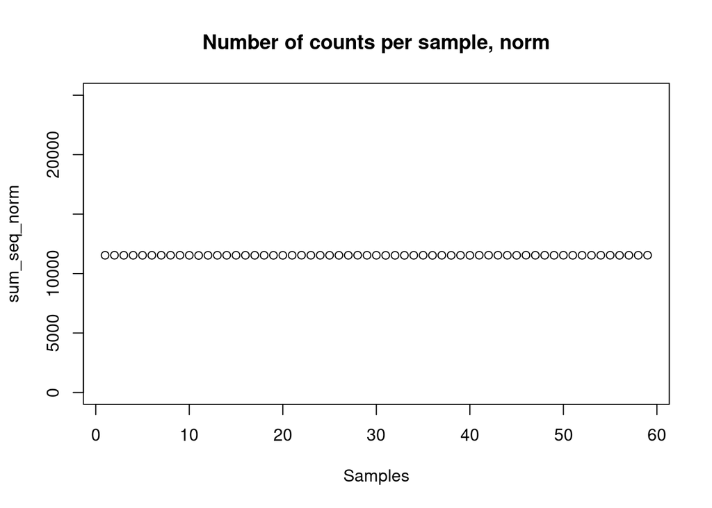

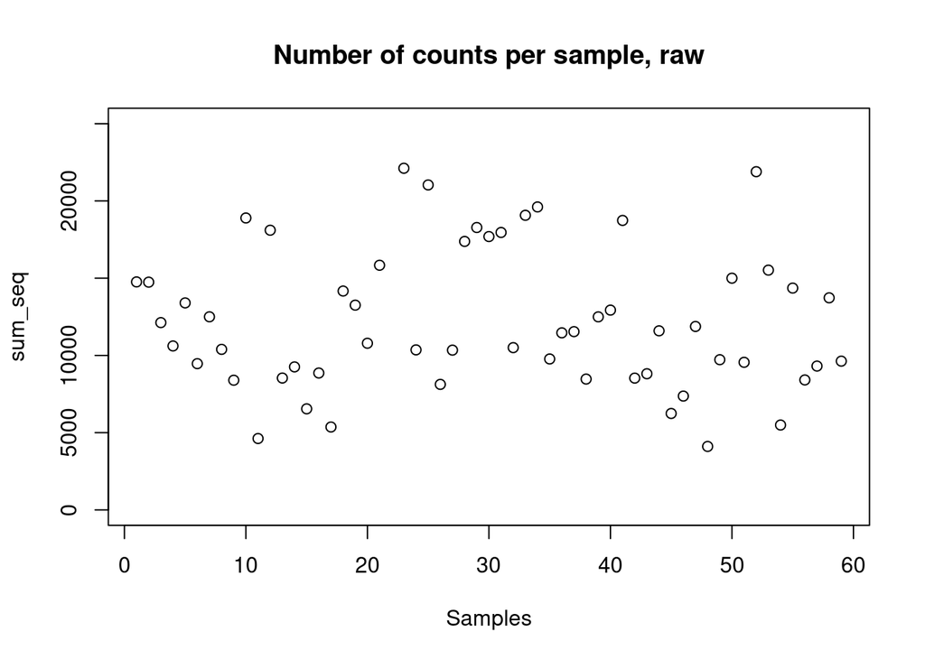

# 3 Интегральные характеристики

Давайте сначала опишем простые вещи

## 3.1 Таблица

|  | Observed | Shannon | Evenness |
| --- | --- | --- | --- |
| L11_L_fab_gut2 | 52 | 1.629467 | 0.4123935 |
| L11_L_fab_gut3 | 43 | 1.391579 | 0.3699828 |
| L11_L_fab_gut4 | 47 | 1.738030 | 0.4514191 |
| L11_L_fab_gut5 | 48 | 1.662301 | 0.4294019 |
| L11_L_fab_gut6 | 30 | 1.465547 | 0.4308914 |
| L11_L_fab_gut7 | 43 | 1.551841 | 0.4125921 |
| L11_L_fab_gut8 | 54 | 1.545353 | 0.3874052 |
| L11_L_fab_tent1 | 49 | 1.838961 | 0.4725196 |
| L11_L_fab_tent2 | 48 | 2.787262 | 0.7199994 |
| L11_L_fill_BF1 | 66 | 1.864167 | 0.4449452 |

[output cut: 49 more lines]

## 3.2 Выровненность и Шеннон общие

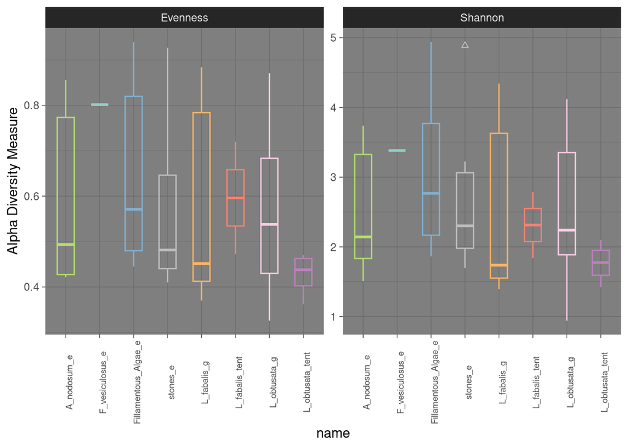

## 3.3 Ранее построенный Шеннон

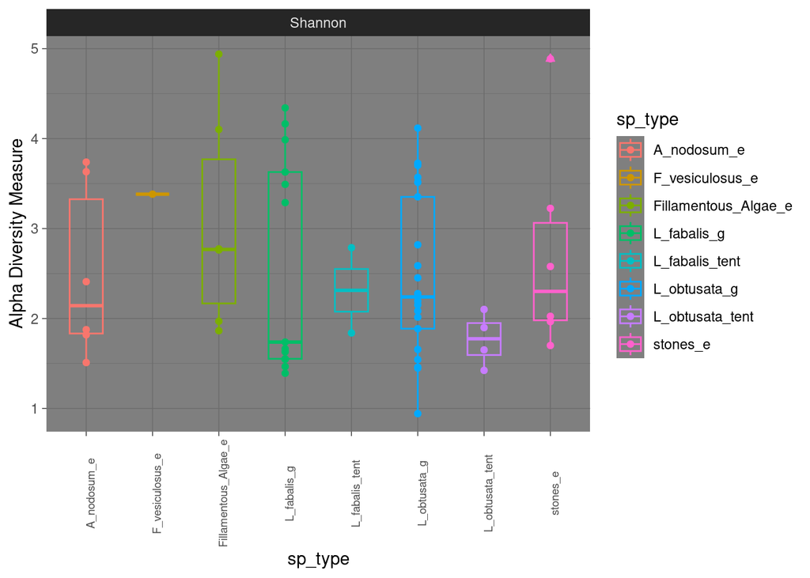

#### 3.3.0.1 Шеннон в кишках, по сезонам на Белом

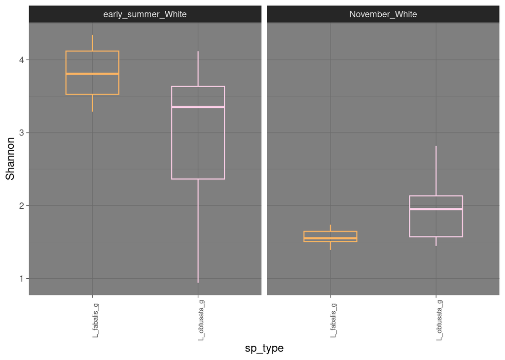

#### 3.3.0.2 Выровненность в кишках, по сезонам на Белом

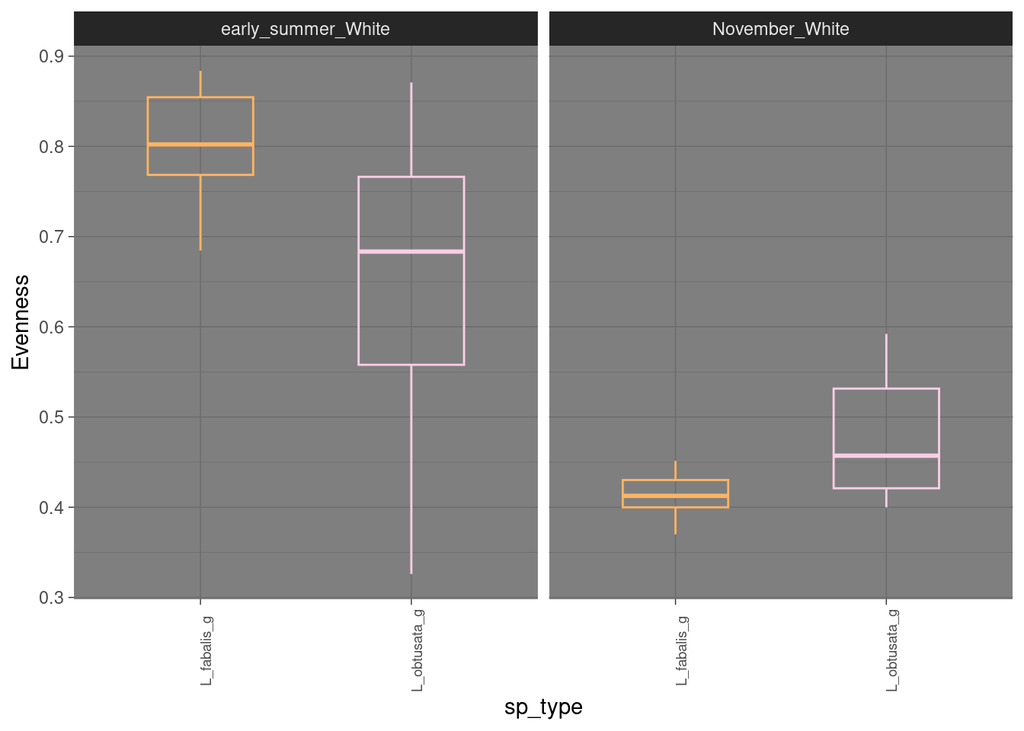

# 4 Ординации и PERMANOVA

Наконец-то многомерный подход

Базово я привыкла делать nMDS по матрице различий Брея-Куртиса, но с некоторыми (напр, логарифмическими нормализациями он не дружит) Можно делать и Жаккара в качестве расстояний, и хоть главные компоненты в качестве ординации Можно делать хитмап или кластеризацию, главное понять, на какие расстояния относит композиция микробиома ваши образцы друг ото друга

```
## Square root transformation
## Wisconsin double standardization
## *** Best solution was not repeated -- monoMDS stopping criteria:
##     20: stress ratio > sratmax
```

```
## [1] 0.1969736
```

## 4.1 Картинки

### 4.1.1 Все точки на одной панели автоматом

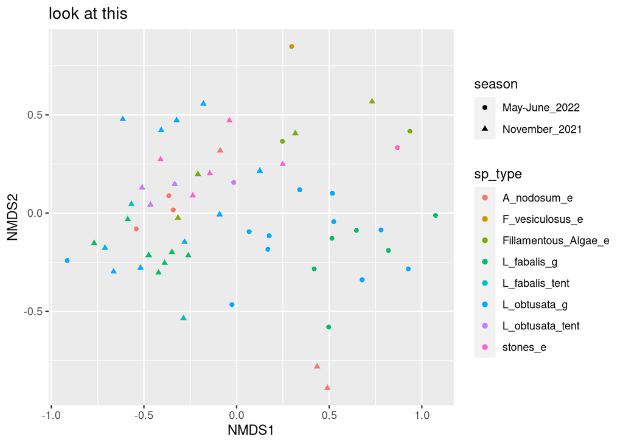

### 4.1.2 Все точки на одной панели руками

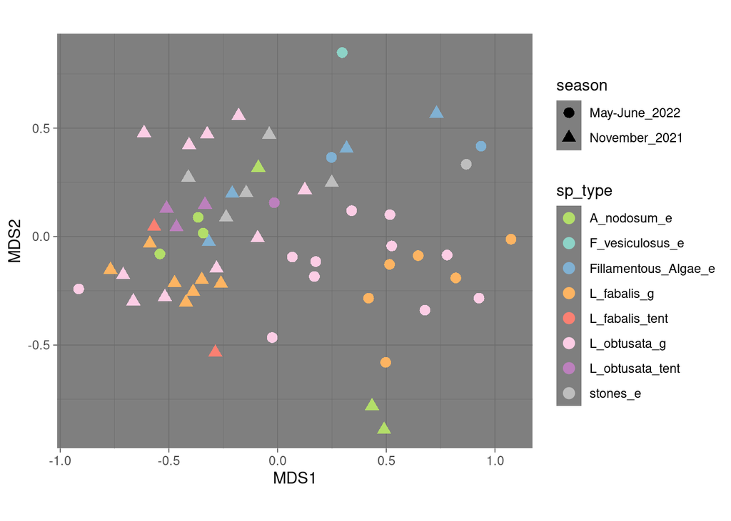

### 4.1.3 Фасетки по сезонам

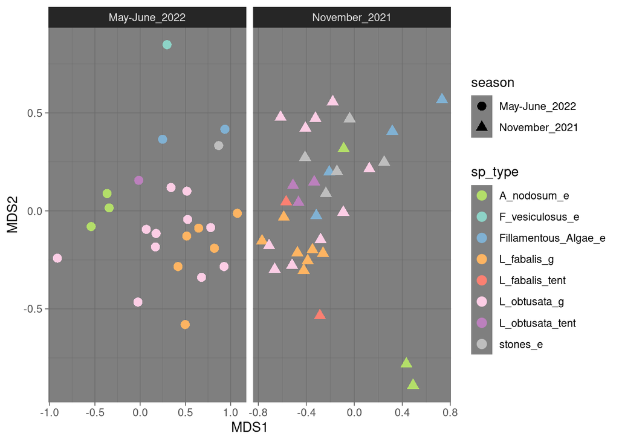

### 4.1.4 Кишечная ординация

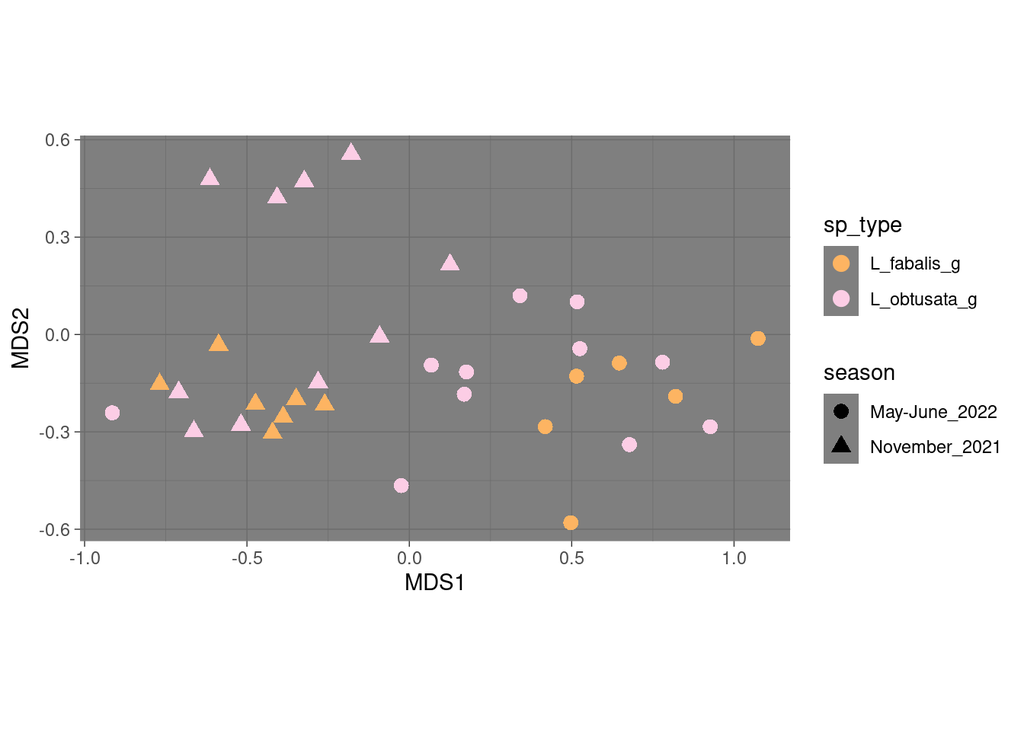

### 4.1.5 Для одного вида

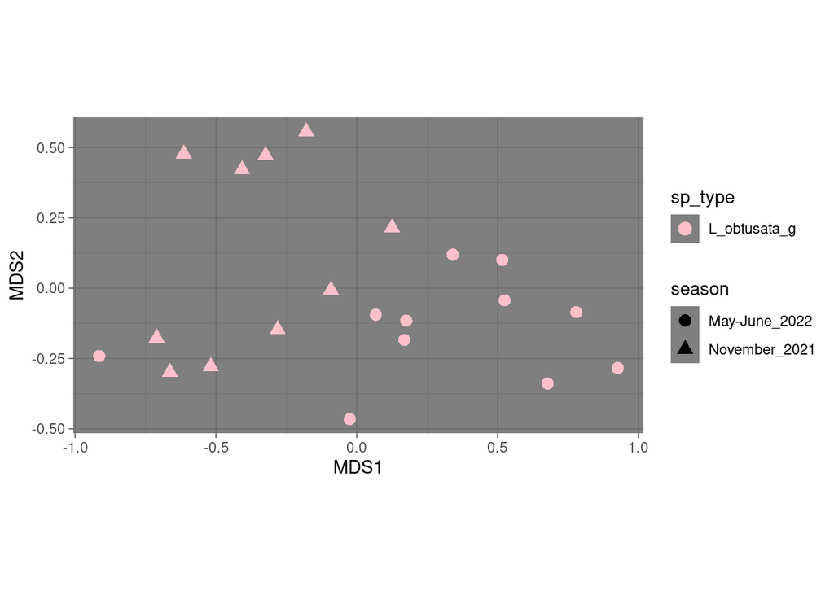

## 4.2 Циферки

будем тестировать с помощью PERMANOVA, есть ли влияние вида для кишечного микробиома и есть ли влияние сезона

### 4.2.1 кишки, 2 сезона, 2 вида, 2 фактора

```
## [1] FALSE
```

```
##
## May-June_2022 November_2021
##            17            17
```

```
##
##  L_fabalis L_obtusata
##         13         21
```

|  | Df | Sum Sq | Mean Sq | F value | Pr(>F) |
| --- | --- | --- | --- | --- | --- |
| Groups | 1 | 0.6031969 | 0.60319686 | 35.83426 | 1.129758e-06 |
| Residuals | 32 | 0.5386549 | 0.01683297 | NA | NA |

|  | Df | Sum Sq | Mean Sq | F value | Pr(>F) |
| --- | --- | --- | --- | --- | --- |
| Groups | 1 | 0.005553382 | 0.005553382 | 0.1097421 | 0.7425976 |
| Residuals | 32 | 1.619325950 | 0.050603936 | NA | NA |

|  | Df | SumOfSqs | R2 | F | Pr(>F) |
| --- | --- | --- | --- | --- | --- |
| season | 1 | 1.3959635 | 0.24319660 | 10.518622 | 0.00001 |
| species | 1 | 0.1596499 | 0.02781327 | 1.202966 | 0.23409 |
| season:species | 1 | 0.2030424 | 0.03537286 | 1.529930 | 0.13423 |
| Residual | 30 | 3.9814060 | 0.69361727 | NA | NA |
| Total | 33 | 5.7400619 | 1.00000000 | NA | NA |

### 4.2.2 кишки летнего сезона, 2 вида, однофакторно

|  | Df | SumOfSqs | R2 | F | Pr(>F) |
| --- | --- | --- | --- | --- | --- |
| species | 1 | 0.3340881 | 0.09512679 | 1.576908 | 0.0892 |
| Residual | 15 | 3.1779417 | 0.90487321 | NA | NA |
| Total | 16 | 3.5120298 | 1.00000000 | NA | NA |

### 4.2.3 кишки летнего сезона, 2 вида, однофакторно, иная перманова

```
##
## Analysis of Variance, using Residual Randomization
## Permutation procedure: Randomization of null model residuals
## Number of permutations: 1000
## Estimation method: Ordinary Least Squares
## Sums of Squares and Cross-products: Type I
## Effect sizes (Z) based on F distributions
##
##           Df     SS      MS     Rsq      F      Z Pr(>F)
## species    1 0.3341 0.33409 0.09513 1.5769 1.3603  0.089 .
## Residuals 15 3.1779 0.21186 0.90487
## Total     16 3.5120
## ---
## Signif. codes:  0 '***' 0.001 '**' 0.01 '*' 0.05 '.' 0.1 ' ' 1
##
## Call: lm.rrpp(f1 = guts_white_bray_snails ~ species, data = guts_white_df)
```

# 5 Барплоты обилия

## 5.1 для всего датасета

### 5.1.1 встроенное в филосек

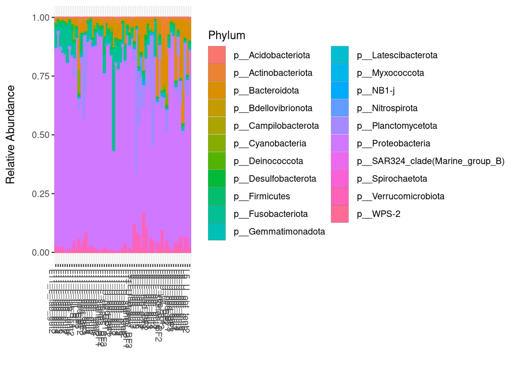

### 5.1.2 специальный пакет для вложенных столбиков

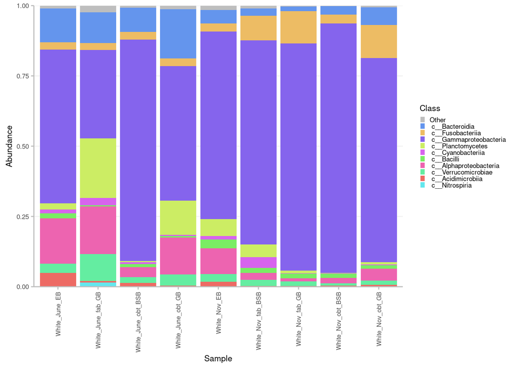

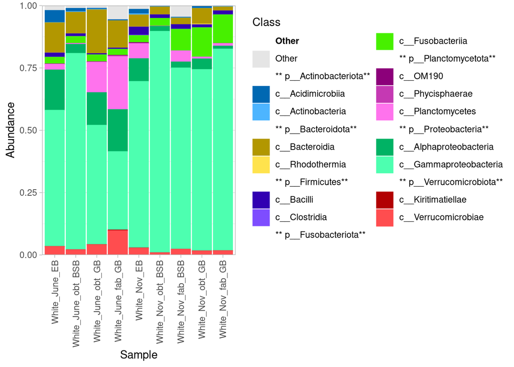

## 5.2 Барплоты для отдельных видов

### 5.2.1 Pseudoalteromonas

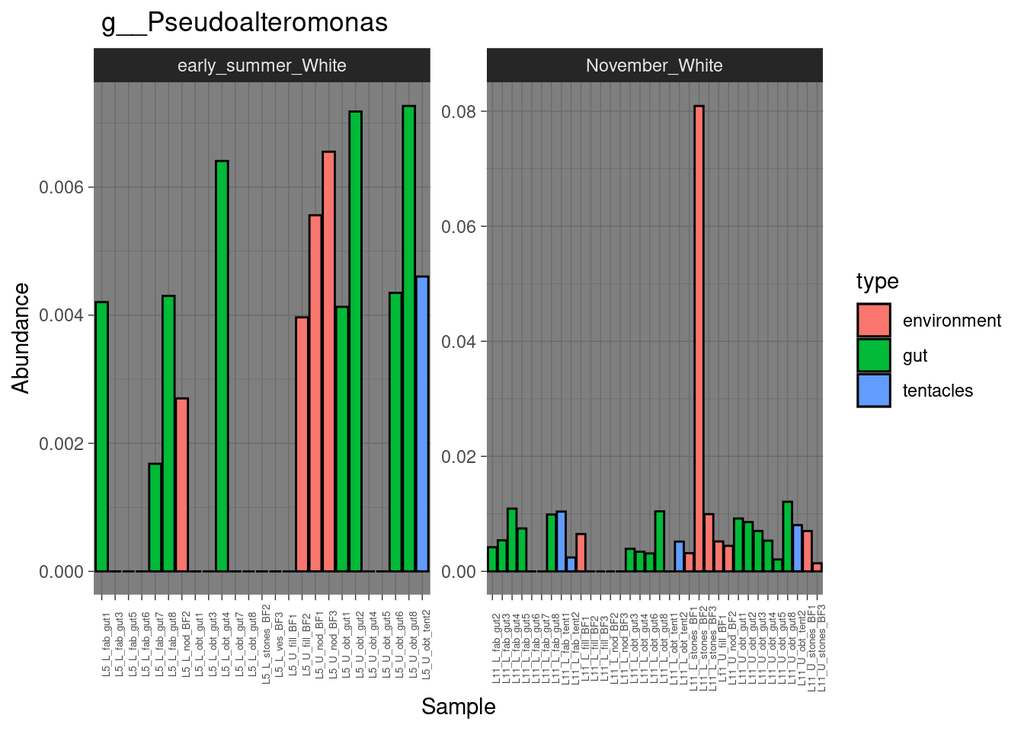

### 5.2.2 Streptococcus

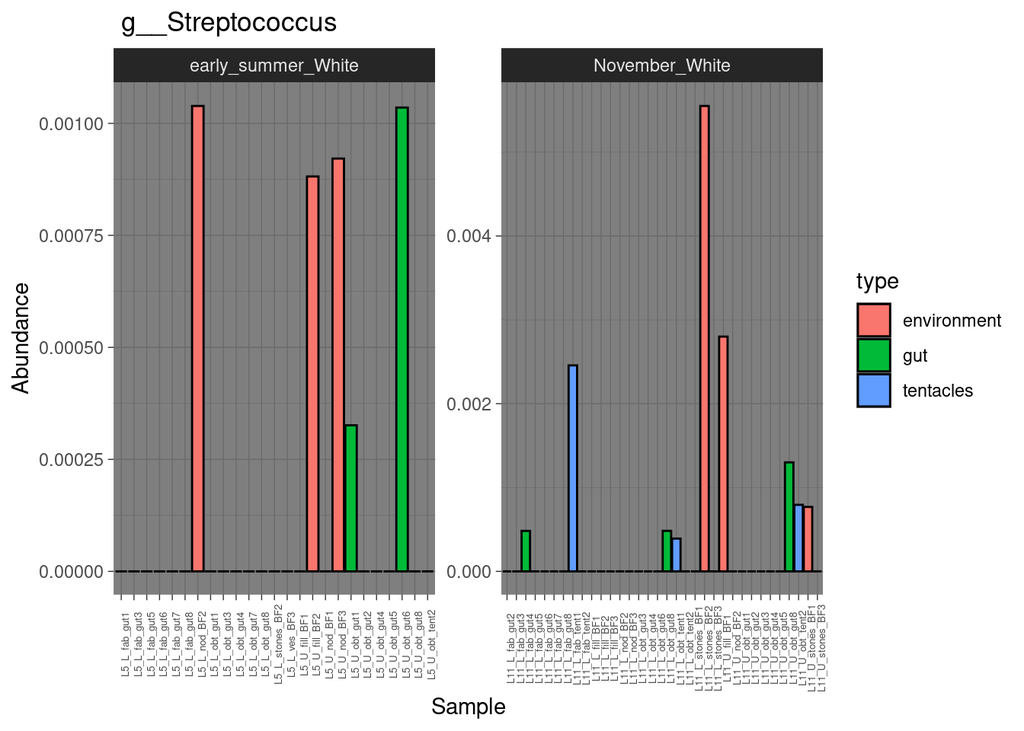

# 6 Бонусный пример хитмапа

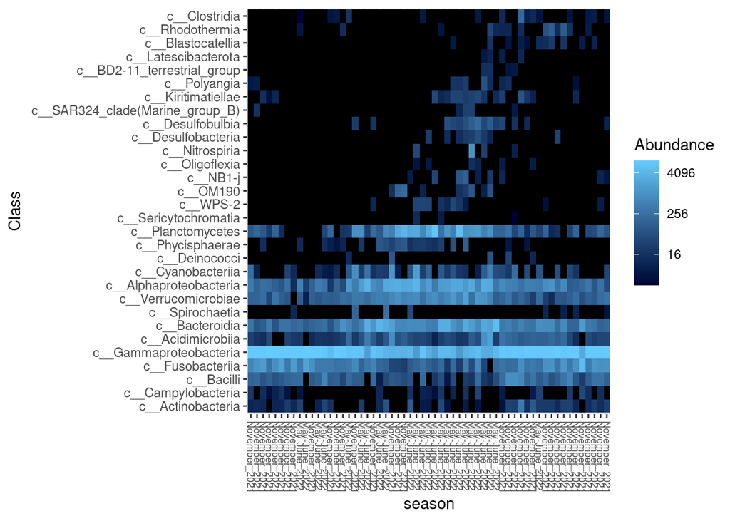